# chronic-kidney-disease-eda-and-prediction

## Introduction

Chronic Kidney disease is the gradual loss of function of the kidney with no symptoms being manifested. <sup>[1](https://en.wikipedia.org/wiki/Chronic_kidney_disease)</sup> It's difficult to know the burden of the disease since they are no accurate diagnostic tests according to research done [here](https://www.sciencedirect.com/science/article/pii/S2214109X14700026). It could be characterized by [uremic frost](https://en.wikipedia.org/wiki/Uremic_frost); however, careful diagnosis of the condition should be followed such as testing kidney function URI scan dripstick test for example the specific gravity -- low values(1.01 - 1.010) could mean that the patient has kidney damage, observation of the urine using microscopy and identification of casts) and other tests can help make a proper diagnosis.

In this notebook, we'll use data with 25 features that could be indicative of chronic kidney disease to see if predictive modelling could help us figure out which patients have chronic kidney disease. You can read more about the dataset using this [link](https://www.kaggle.com/mansoordaku/ckdisease). Let's proceed to exploratory data analysis.

I first import all the packages that could be useful in wrangling, visualization and statistical modelling. I apologise if there's a package here that I have imported but I haven't used it. It may have slipped my mind for some reason.

```python
import numpy as np # numeric processing
import pandas as pd # data processing, CSV file I/O (e.g. pd.read_csv)
from sklearn.feature_extraction import DictVectorizer
from sklearn.impute import SimpleImputer
from sklearn.model_selection import train_test_split
from IPython.display import HTML
from sklearn.pipeline import Pipeline
from sklearn.model_selection import cross_val_score
from sklearn.model_selection import StratifiedShuffleSplit
from sklearn.model_selection import train_test_split
from sklearn.decomposition import PCA
from sklearn.ensemble import RandomForestClassifier
from sklearn.linear_model import LogisticRegression
from sklearn.model_selection import GridSearchCV
from sklearn.metrics import f1_score, classification_report
from sklearn.tree import DecisionTreeClassifier
from sklearn.preprocessing import StandardScaler
from functools import *
from pandas_profiling import ProfileReport
import matplotlib.pyplot as plt
from sklearn.pipeline import Pipeline
```

Turicreate is a machine learning library by apple. There's some functionality that I was interested in that I wanted to try. In future, I may add it to the notebook. If you want more information about the library. Find for information [here.](https://github.com/apple/turicreate)

```python
!pip install turicreate -q
```

[output not shown]

## Loading data and Exploratory data analysis

In this analysis, we'll do predictive modelling in hopes of finding a model which will be able to classify the patients appropriately.

```python
# load the dataset with pandas read_csv function
df = pd.read_csv('../input/kidney_disease.csv', index_col="id")

# give the dtypes of the columns if the data was squeeky clean
dtypes = {
    'id' : np.int32,
    'age' : np.int32,
    'bp' : np.float32,
    'sg' : np.object, # category
    'al' : np.object, # category # mistake
    'su' : np.object, #category  # mistake
    'rbc' : np.object, # category
    'pc' : np.object, # category
    'pcc' : np.object, # category
    'ba' : np.object, # category
    'bgr' : np.float32,
    'bu' : np.int32,
    'sc' : np.float32,
    'sod': np.int32,
    'pot' : np.float32,
    'hemo' : np.float32,
    'pcv' : np.int32,
    'wc' : np.int32,
    'rc' : np.int32,
    'htn' : np.object,
    'dm' : np.object,
    'cad' : np.object,
    'appet': np.object,
    'pe' : np.object,
    'ane' : np.object,
    'class': np.object}

# another way of reading in the datasets especially very big files like 1GB big
# df2 = dd.read_csv('../input/kidney_disease.csv', dtype=dtypes)
# id                400 non-null int64
# age               391 non-null float64
# bp                388 non-null float64
# sg                353 non-null float64
# al                354 non-null float64
# su                351 non-null float64
# rbc               248 non-null object
# pc                335 non-null object
# pcc               396 non-null object
# ba                396 non-null object
# bgr               356 non-null float64
# bu                381 non-null float64
# sc                383 non-null float64
# sod               313 non-null float64
# pot               312 non-null float64
# hemo              348 non-null float64
# pcv               330 non-null object
# wc                295 non-null object
# rc                270 non-null object
# htn               398 non-null object
# dm                398 non-null object
# cad               398 non-null object
# appet             399 non-null object
# pe                399 non-null object
# ane               399 non-null object
# classification    400 non-null object
```

```python
# see the first couple of observations and transpose 10 observations
# think of it as rolling over your dataset
df.head(10).transpose()
```

| id | 0 | 1 | 2 | 3 | 4 | 5 | 6 | 7 | 8 | 9 |
| --- | --- | --- | --- | --- | --- | --- | --- | --- | --- | --- |
| age | 48 | 7 | 62 | 48 | 51 | 60 | 68 | 24 | 52 | 53 |
| bp | 80 | 50 | 80 | 70 | 80 | 90 | 70 | NaN | 100 | 90 |
| sg | 1.02 | 1.02 | 1.01 | 1.005 | 1.01 | 1.015 | 1.01 | 1.015 | 1.015 | 1.02 |
| al | 1 | 4 | 2 | 4 | 2 | 3 | 0 | 2 | 3 | 2 |
| su | 0 | 0 | 3 | 0 | 0 | 0 | 0 | 4 | 0 | 0 |
| rbc | NaN | NaN | normal | normal | normal | NaN | NaN | normal | normal | abnormal |
| pc | normal | normal | normal | abnormal | normal | NaN | normal | abnormal | abnormal | abnormal |
| pcc | notpresent | notpresent | notpresent | present | notpresent | notpresent | notpresent | notpresent | present | present |
| ba | notpresent | notpresent | notpresent | notpresent | notpresent | notpresent | notpresent | notpresent | notpresent | notpresent |
| bgr | 121 | NaN | 423 | 117 | 106 | 74 | 100 | 410 | 138 | 70 |
| bu | 36 | 18 | 53 | 56 | 26 | 25 | 54 | 31 | 60 | 107 |
| sc | 1.2 | 0.8 | 1.8 | 3.8 | 1.4 | 1.1 | 24 | 1.1 | 1.9 | 7.2 |
| sod | NaN | NaN | NaN | 111 | NaN | 142 | 104 | NaN | NaN | 114 |
| pot | NaN | NaN | NaN | 2.5 | NaN | 3.2 | 4 | NaN | NaN | 3.7 |
| hemo | 15.4 | 11.3 | 9.6 | 11.2 | 11.6 | 12.2 | 12.4 | 12.4 | 10.8 | 9.5 |
| pcv | 44 | 38 | 31 | 32 | 35 | 39 | 36 | 44 | 33 | 29 |
| wc | 7800 | 6000 | 7500 | 6700 | 7300 | 7800 | NaN | 6900 | 9600 | 12100 |
| rc | 5.2 | NaN | NaN | 3.9 | 4.6 | 4.4 | NaN | 5 | 4.0 | 3.7 |
| htn | yes | no | no | yes | no | yes | no | no | yes | yes |
| dm | yes | no | yes | no | no | yes | no | yes | yes | yes |
| cad | no | no | no | no | no | no | no | no | no | no |
| appet | good | good | poor | poor | good | good | good | good | good | poor |
| pe | no | no | no | yes | no | yes | no | yes | no | no |
| ane | no | no | yes | yes | no | no | no | no | yes | yes |
| classification | ckd | ckd | ckd | ckd | ckd | ckd | ckd | ckd | ckd | ckd |

```python
# see the column names
df.columns
```

```
Index(['age', 'bp', 'sg', 'al', 'su', 'rbc', 'pc', 'pcc', 'ba', 'bgr', 'bu',
       'sc', 'sod', 'pot', 'hemo', 'pcv', 'wc', 'rc', 'htn', 'dm', 'cad',
       'appet', 'pe', 'ane', 'classification'],
      dtype='object')
```

```python
# see a concise summary of the dataset
df.info()
```

```
<class 'pandas.core.frame.DataFrame'>
Int64Index: 400 entries, 0 to 399
Data columns (total 25 columns):
age               391 non-null float64
bp                388 non-null float64
sg                353 non-null float64
al                354 non-null float64
su                351 non-null float64
rbc               248 non-null object
pc                335 non-null object
pcc               396 non-null object
ba                396 non-null object
bgr               356 non-null float64
bu                381 non-null float64
sc                383 non-null float64
sod               313 non-null float64
pot               312 non-null float64
hemo              348 non-null float64
pcv               330 non-null object
wc                295 non-null object
rc                270 non-null object
htn               398 non-null object
dm                398 non-null object
cad               398 non-null object
appet             399 non-null object
pe                399 non-null object
ane               399 non-null object
classification    400 non-null object
dtypes: float64(11), object(14)
memory usage: 81.2+ KB
```

```python
# display summary statistics of each column
# this helps me confirm my assertion on missing data
df.describe(include="all").transpose()
```

|  | count | unique | top | freq | mean | std | min | 25% | 50% | 75% | max |
| --- | --- | --- | --- | --- | --- | --- | --- | --- | --- | --- | --- |
| age | 391 | NaN | NaN | NaN | 51.4834 | 17.1697 | 2 | 42 | 55 | 64.5 | 90 |
| bp | 388 | NaN | NaN | NaN | 76.4691 | 13.6836 | 50 | 70 | 80 | 80 | 180 |
| sg | 353 | NaN | NaN | NaN | 1.01741 | 0.00571662 | 1.005 | 1.01 | 1.02 | 1.02 | 1.025 |
| al | 354 | NaN | NaN | NaN | 1.01695 | 1.35268 | 0 | 0 | 0 | 2 | 5 |
| su | 351 | NaN | NaN | NaN | 0.450142 | 1.09919 | 0 | 0 | 0 | 0 | 5 |
| rbc | 248 | 2 | normal | 201 | NaN | NaN | NaN | NaN | NaN | NaN | NaN |
| pc | 335 | 2 | normal | 259 | NaN | NaN | NaN | NaN | NaN | NaN | NaN |
| pcc | 396 | 2 | notpresent | 354 | NaN | NaN | NaN | NaN | NaN | NaN | NaN |
| ba | 396 | 2 | notpresent | 374 | NaN | NaN | NaN | NaN | NaN | NaN | NaN |
| bgr | 356 | NaN | NaN | NaN | 148.037 | 79.2817 | 22 | 99 | 121 | 163 | 490 |
| bu | 381 | NaN | NaN | NaN | 57.4257 | 50.503 | 1.5 | 27 | 42 | 66 | 391 |
| sc | 383 | NaN | NaN | NaN | 3.07245 | 5.74113 | 0.4 | 0.9 | 1.3 | 2.8 | 76 |
| sod | 313 | NaN | NaN | NaN | 137.529 | 10.4088 | 4.5 | 135 | 138 | 142 | 163 |
| pot | 312 | NaN | NaN | NaN | 4.62724 | 3.1939 | 2.5 | 3.8 | 4.4 | 4.9 | 47 |
| hemo | 348 | NaN | NaN | NaN | 12.5264 | 2.91259 | 3.1 | 10.3 | 12.65 | 15 | 17.8 |
| pcv | 330 | 44 | 52 | 21 | NaN | NaN | NaN | NaN | NaN | NaN | NaN |
| wc | 295 | 92 | 9800 | 11 | NaN | NaN | NaN | NaN | NaN | NaN | NaN |
| rc | 270 | 49 | 5.2 | 18 | NaN | NaN | NaN | NaN | NaN | NaN | NaN |
| htn | 398 | 2 | no | 251 | NaN | NaN | NaN | NaN | NaN | NaN | NaN |
| dm | 398 | 5 | no | 258 | NaN | NaN | NaN | NaN | NaN | NaN | NaN |
| cad | 398 | 3 | no | 362 | NaN | NaN | NaN | NaN | NaN | NaN | NaN |
| appet | 399 | 2 | good | 317 | NaN | NaN | NaN | NaN | NaN | NaN | NaN |
| pe | 399 | 2 | no | 323 | NaN | NaN | NaN | NaN | NaN | NaN | NaN |
| ane | 399 | 2 | no | 339 | NaN | NaN | NaN | NaN | NaN | NaN | NaN |
| classification | 400 | 3 | ckd | 248 | NaN | NaN | NaN | NaN | NaN | NaN | NaN |

Overview

Dataset info

| Number of variables | 25 |
| --- | --- |
| Number of observations | 400 |
| Total Missing (%) | 10.1% |
| Total size in memory | 81.2 KiB |
| Average record size in memory | 208.0 B |

Variables types

| Numeric | 11 |
| --- | --- |
| Categorical | 14 |
| Boolean | 0 |
| Date | 0 |
| Text (Unique) | 0 |
| Rejected | 0 |
| Unsupported | 0 |

Warnings

- `age` has 9 / 2.2% missing values Missing

- `al` has 199 / 49.8% zeros Zeros

- `al` has 46 / 11.5% missing values Missing

- `ba` has 4 / 1.0% missing values Missing

- `bgr` has 44 / 11.0% missing values Missing

- `bp` has 12 / 3.0% missing values Missing

- `bu` has 19 / 4.7% missing values Missing

- `hemo` has 52 / 13.0% missing values Missing

- `pc` has 65 / 16.2% missing values Missing

- `pcc` has 4 / 1.0% missing values Missing

- `pcv` has 70 / 17.5% missing values Missing

- `pot` has 88 / 22.0% missing values Missing

- `rbc` has 152 / 38.0% missing values Missing

- `rc` has 130 / 32.5% missing values Missing

- `sc` has 17 / 4.2% missing values Missing

- `sg` has 47 / 11.8% missing values Missing

- `sod` has 87 / 21.8% missing values Missing

- `su` has 290 / 72.5% zeros Zeros

- `su` has 49 / 12.3% missing values Missing

- `wc` has 105 / 26.2% missing values Missing

- `wc` has a high cardinality: 93 distinct values Warning

Variables

age  
Numeric

| Distinct count | 77 |
| --- | --- |
| Unique (%) | 19.2% |
| Missing (%) | 2.2% |
| Missing (n) | 9 |
| Infinite (%) | 0.0% |
| Infinite (n) | 0 |

| Mean | 51.483 |
| --- | --- |
| Minimum | 2 |
| Maximum | 90 |
| Zeros (%) | 0.0% |

Toggle details

**Statistics**

Quantile statistics

| Minimum | 2 |
| --- | --- |
| 5-th percentile | 19 |
| Q1 | 42 |
| Median | 55 |
| Q3 | 64.5 |
| 95-th percentile | 74.5 |
| Maximum | 90 |
| Range | 88 |
| Interquartile range | 22.5 |

Descriptive statistics

| Standard deviation | 17.17 |
| --- | --- |
| Coef of variation | 0.3335 |
| Kurtosis | 0.05784 |
| Mean | 51.483 |
| MAD | 13.814 |
| Skewness | -0.66826 |
| Sum | 20130 |
| Variance | 294.8 |
| Memory size | 6.2 KiB |

**Histogram**

[figure not shown]

**Common Values**

| Value | Count | Frequency (%) |  |
| --- | --- | --- | --- |
| 60.0 | 19 | 4.8% |  |
| 65.0 | 17 | 4.2% |  |
| 48.0 | 12 | 3.0% |  |
| 50.0 | 12 | 3.0% |  |
| 55.0 | 12 | 3.0% |  |
| 47.0 | 11 | 2.8% |  |
| 62.0 | 10 | 2.5% |  |
| 56.0 | 10 | 2.5% |  |
| 45.0 | 10 | 2.5% |  |
| 54.0 | 10 | 2.5% |  |
| Other values (66) | 268 | 67.0% |  |

**Extreme Values**

Minimum 5 values

| Value | Count | Frequency (%) |  |
| --- | --- | --- | --- |
| 2.0 | 1 | 0.2% |  |
| 3.0 | 1 | 0.2% |  |
| 4.0 | 1 | 0.2% |  |
| 5.0 | 2 | 0.5% |  |
| 6.0 | 1 | 0.2% |  |

Maximum 5 values

| Value | Count | Frequency (%) |  |
| --- | --- | --- | --- |
| 80.0 | 4 | 1.0% |  |
| 81.0 | 1 | 0.2% |  |
| 82.0 | 1 | 0.2% |  |
| 83.0 | 1 | 0.2% |  |
| 90.0 | 1 | 0.2% |  |

al  
Numeric

| Distinct count | 7 |
| --- | --- |
| Unique (%) | 1.8% |
| Missing (%) | 11.5% |
| Missing (n) | 46 |
| Infinite (%) | 0.0% |
| Infinite (n) | 0 |

| Mean | 1.0169 |
| --- | --- |
| Minimum | 0 |
| Maximum | 5 |
| Zeros (%) | 49.8% |

Toggle details

**Statistics**

Quantile statistics

| Minimum | 0 |
| --- | --- |
| 5-th percentile | 0 |
| Q1 | 0 |
| Median | 0 |
| Q3 | 2 |
| 95-th percentile | 4 |
| Maximum | 5 |
| Range | 5 |
| Interquartile range | 2 |

Descriptive statistics

| Standard deviation | 1.3527 |
| --- | --- |
| Coef of variation | 1.3301 |
| Kurtosis | -0.38338 |
| Mean | 1.0169 |
| MAD | 1.1476 |
| Skewness | 0.99816 |
| Sum | 360 |
| Variance | 1.8297 |
| Memory size | 6.2 KiB |

**Histogram**

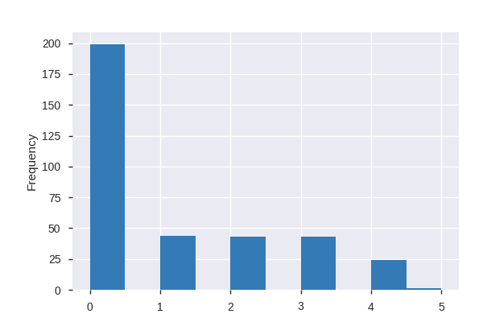

**Common Values**

| Value | Count | Frequency (%) |  |
| --- | --- | --- | --- |
| 0.0 | 199 | 49.8% |  |
| 1.0 | 44 | 11.0% |  |
| 3.0 | 43 | 10.8% |  |
| 2.0 | 43 | 10.8% |  |
| 4.0 | 24 | 6.0% |  |
| 5.0 | 1 | 0.2% |  |
| (Missing) | 46 | 11.5% |  |

**Extreme Values**

Minimum 5 values

| Value | Count | Frequency (%) |  |
| --- | --- | --- | --- |
| 0.0 | 199 | 49.8% |  |
| 1.0 | 44 | 11.0% |  |
| 2.0 | 43 | 10.8% |  |
| 3.0 | 43 | 10.8% |  |
| 4.0 | 24 | 6.0% |  |

Maximum 5 values

| Value | Count | Frequency (%) |  |
| --- | --- | --- | --- |
| 1.0 | 44 | 11.0% |  |
| 2.0 | 43 | 10.8% |  |
| 3.0 | 43 | 10.8% |  |
| 4.0 | 24 | 6.0% |  |
| 5.0 | 1 | 0.2% |  |

ane  
Categorical

| Distinct count | 3 |
| --- | --- |
| Unique (%) | 0.8% |
| Missing (%) | 0.2% |
| Missing (n) | 1 |

| no | 339 |
| --- | --- |
| yes | 60 |
| (Missing) | 1 |

Toggle details

| Value | Count | Frequency (%) |  |
| --- | --- | --- | --- |
| no | 339 | 84.8% |  |
| yes | 60 | 15.0% |  |
| (Missing) | 1 | 0.2% |  |

appet  
Categorical

| Distinct count | 3 |
| --- | --- |
| Unique (%) | 0.8% |
| Missing (%) | 0.2% |
| Missing (n) | 1 |

| good | 317 |
| --- | --- |
| poor | 82 |
| (Missing) | 1 |

Toggle details

| Value | Count | Frequency (%) |  |
| --- | --- | --- | --- |
| good | 317 | 79.2% |  |
| poor | 82 | 20.5% |  |
| (Missing) | 1 | 0.2% |  |

ba  
Categorical

| Distinct count | 3 |
| --- | --- |
| Unique (%) | 0.8% |
| Missing (%) | 1.0% |
| Missing (n) | 4 |

| notpresent | 374 |
| --- | --- |
| present | 22 |
| (Missing) | 4 |

Toggle details

| Value | Count | Frequency (%) |  |
| --- | --- | --- | --- |
| notpresent | 374 | 93.5% |  |
| present | 22 | 5.5% |  |
| (Missing) | 4 | 1.0% |  |

bgr  
Numeric

| Distinct count | 147 |
| --- | --- |
| Unique (%) | 36.8% |
| Missing (%) | 11.0% |
| Missing (n) | 44 |
| Infinite (%) | 0.0% |
| Infinite (n) | 0 |

| Mean | 148.04 |
| --- | --- |
| Minimum | 22 |
| Maximum | 490 |
| Zeros (%) | 0.0% |

Toggle details

**Statistics**

Quantile statistics

| Minimum | 22 |
| --- | --- |
| 5-th percentile | 78.75 |
| Q1 | 99 |
| Median | 121 |
| Q3 | 163 |
| 95-th percentile | 307.25 |
| Maximum | 490 |
| Range | 468 |
| Interquartile range | 64 |

Descriptive statistics

| Standard deviation | 79.282 |
| --- | --- |
| Coef of variation | 0.53556 |
| Kurtosis | 4.2256 |
| Mean | 148.04 |
| MAD | 57.069 |
| Skewness | 2.0108 |
| Sum | 52701 |
| Variance | 6285.6 |
| Memory size | 6.2 KiB |

**Histogram**

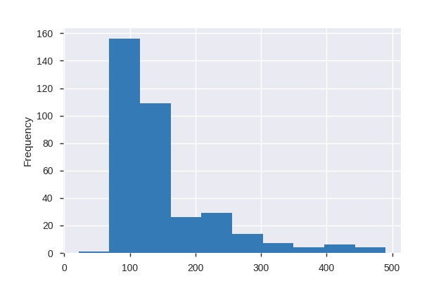

**Common Values**

| Value | Count | Frequency (%) |  |
| --- | --- | --- | --- |
| 99.0 | 10 | 2.5% |  |
| 93.0 | 9 | 2.2% |  |
| 100.0 | 9 | 2.2% |  |
| 107.0 | 8 | 2.0% |  |
| 131.0 | 6 | 1.5% |  |
| 92.0 | 6 | 1.5% |  |
| 109.0 | 6 | 1.5% |  |
| 140.0 | 6 | 1.5% |  |
| 130.0 | 6 | 1.5% |  |
| 117.0 | 6 | 1.5% |  |
| Other values (136) | 284 | 71.0% |  |
| (Missing) | 44 | 11.0% |  |

**Extreme Values**

Minimum 5 values

| Value | Count | Frequency (%) |  |
| --- | --- | --- | --- |
| 22.0 | 1 | 0.2% |  |
| 70.0 | 5 | 1.2% |  |
| 74.0 | 3 | 0.8% |  |
| 75.0 | 2 | 0.5% |  |
| 76.0 | 4 | 1.0% |  |

Maximum 5 values

| Value | Count | Frequency (%) |  |
| --- | --- | --- | --- |
| 424.0 | 2 | 0.5% |  |
| 425.0 | 1 | 0.2% |  |
| 447.0 | 1 | 0.2% |  |
| 463.0 | 1 | 0.2% |  |
| 490.0 | 2 | 0.5% |  |

bp  
Numeric

| Distinct count | 11 |
| --- | --- |
| Unique (%) | 2.8% |
| Missing (%) | 3.0% |
| Missing (n) | 12 |
| Infinite (%) | 0.0% |
| Infinite (n) | 0 |

| Mean | 76.469 |
| --- | --- |
| Minimum | 50 |
| Maximum | 180 |
| Zeros (%) | 0.0% |

Toggle details

**Statistics**

Quantile statistics

| Minimum | 50 |
| --- | --- |
| 5-th percentile | 60 |
| Q1 | 70 |
| Median | 80 |
| Q3 | 80 |
| 95-th percentile | 100 |
| Maximum | 180 |
| Range | 130 |
| Interquartile range | 10 |

Descriptive statistics

| Standard deviation | 13.684 |
| --- | --- |
| Coef of variation | 0.17894 |
| Kurtosis | 8.6461 |
| Mean | 76.469 |
| MAD | 10.444 |
| Skewness | 1.6054 |
| Sum | 29670 |
| Variance | 187.24 |
| Memory size | 6.2 KiB |

**Histogram**

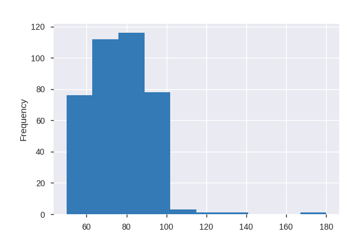

**Common Values**

| Value | Count | Frequency (%) |  |
| --- | --- | --- | --- |
| 80.0 | 116 | 29.0% |  |
| 70.0 | 112 | 28.0% |  |
| 60.0 | 71 | 17.8% |  |
| 90.0 | 53 | 13.2% |  |
| 100.0 | 25 | 6.2% |  |
| 50.0 | 5 | 1.2% |  |
| 110.0 | 3 | 0.8% |  |
| 120.0 | 1 | 0.2% |  |
| 180.0 | 1 | 0.2% |  |
| 140.0 | 1 | 0.2% |  |
| (Missing) | 12 | 3.0% |  |

**Extreme Values**

Minimum 5 values

| Value | Count | Frequency (%) |  |
| --- | --- | --- | --- |
| 50.0 | 5 | 1.2% |  |
| 60.0 | 71 | 17.8% |  |
| 70.0 | 112 | 28.0% |  |
| 80.0 | 116 | 29.0% |  |
| 90.0 | 53 | 13.2% |  |

Maximum 5 values

| Value | Count | Frequency (%) |  |
| --- | --- | --- | --- |
| 100.0 | 25 | 6.2% |  |
| 110.0 | 3 | 0.8% |  |
| 120.0 | 1 | 0.2% |  |
| 140.0 | 1 | 0.2% |  |
| 180.0 | 1 | 0.2% |  |

bu  
Numeric

| Distinct count | 119 |
| --- | --- |
| Unique (%) | 29.8% |
| Missing (%) | 4.7% |
| Missing (n) | 19 |
| Infinite (%) | 0.0% |
| Infinite (n) | 0 |

| Mean | 57.426 |
| --- | --- |
| Minimum | 1.5 |
| Maximum | 391 |
| Zeros (%) | 0.0% |

Toggle details

**Statistics**

Quantile statistics

| Minimum | 1.5 |
| --- | --- |
| 5-th percentile | 17 |
| Q1 | 27 |
| Median | 42 |
| Q3 | 66 |
| 95-th percentile | 162 |
| Maximum | 391 |
| Range | 389.5 |
| Interquartile range | 39 |

Descriptive statistics

| Standard deviation | 50.503 |
| --- | --- |
| Coef of variation | 0.87945 |
| Kurtosis | 9.3453 |
| Mean | 57.426 |
| MAD | 34.155 |
| Skewness | 2.6344 |
| Sum | 21879 |
| Variance | 2550.6 |
| Memory size | 6.2 KiB |

**Histogram**

[figure not shown]

**Common Values**

| Value | Count | Frequency (%) |  |
| --- | --- | --- | --- |
| 46.0 | 15 | 3.8% |  |
| 25.0 | 13 | 3.2% |  |
| 19.0 | 11 | 2.8% |  |
| 40.0 | 10 | 2.5% |  |
| 18.0 | 9 | 2.2% |  |
| 15.0 | 9 | 2.2% |  |
| 48.0 | 9 | 2.2% |  |
| 50.0 | 9 | 2.2% |  |
| 32.0 | 8 | 2.0% |  |
| 26.0 | 8 | 2.0% |  |
| Other values (108) | 280 | 70.0% |  |
| (Missing) | 19 | 4.8% |  |

**Extreme Values**

Minimum 5 values

| Value | Count | Frequency (%) |  |
| --- | --- | --- | --- |
| 1.5 | 1 | 0.2% |  |
| 10.0 | 2 | 0.5% |  |
| 15.0 | 9 | 2.2% |  |
| 16.0 | 7 | 1.8% |  |
| 17.0 | 7 | 1.8% |  |

Maximum 5 values

| Value | Count | Frequency (%) |  |
| --- | --- | --- | --- |
| 235.0 | 1 | 0.2% |  |
| 241.0 | 1 | 0.2% |  |
| 309.0 | 1 | 0.2% |  |
| 322.0 | 1 | 0.2% |  |
| 391.0 | 1 | 0.2% |  |

cad  
Categorical

| Distinct count | 4 |
| --- | --- |
| Unique (%) | 1.0% |
| Missing (%) | 0.5% |
| Missing (n) | 2 |

| no | 362 |
| --- | --- |
| yes | 34 |
| no | 2 |
| (Missing) | 2 |

Toggle details

| Value | Count | Frequency (%) |  |
| --- | --- | --- | --- |
| no | 362 | 90.5% |  |
| yes | 34 | 8.5% |  |
| no | 2 | 0.5% |  |
| (Missing) | 2 | 0.5% |  |

classification  
Categorical

| Distinct count | 3 |
| --- | --- |
| Unique (%) | 0.8% |
| Missing (%) | 0.0% |
| Missing (n) | 0 |

| ckd | 248 |
| --- | --- |
| notckd | 150 |
| ckd | 2 |

Toggle details

| Value | Count | Frequency (%) |  |
| --- | --- | --- | --- |
| ckd | 248 | 62.0% |  |
| notckd | 150 | 37.5% |  |
| ckd | 2 | 0.5% |  |

dm  
Categorical

| Distinct count | 6 |
| --- | --- |
| Unique (%) | 1.5% |
| Missing (%) | 0.5% |
| Missing (n) | 2 |

| no | 258 |
| --- | --- |
| yes | 134 |
| no | 3 |
| Other values (2) | 3 |

Toggle details

| Value | Count | Frequency (%) |  |
| --- | --- | --- | --- |
| no | 258 | 64.5% |  |
| yes | 134 | 33.5% |  |
| no | 3 | 0.8% |  |
| yes | 2 | 0.5% |  |
| yes | 1 | 0.2% |  |
| (Missing) | 2 | 0.5% |  |

hemo  
Numeric

| Distinct count | 116 |
| --- | --- |
| Unique (%) | 29.0% |
| Missing (%) | 13.0% |
| Missing (n) | 52 |
| Infinite (%) | 0.0% |
| Infinite (n) | 0 |

| Mean | 12.526 |
| --- | --- |
| Minimum | 3.1 |
| Maximum | 17.8 |
| Zeros (%) | 0.0% |

Toggle details

**Statistics**

Quantile statistics

| Minimum | 3.1 |
| --- | --- |
| 5-th percentile | 7.9 |
| Q1 | 10.3 |
| Median | 12.65 |
| Q3 | 15 |
| 95-th percentile | 16.9 |
| Maximum | 17.8 |
| Range | 14.7 |
| Interquartile range | 4.7 |

Descriptive statistics

| Standard deviation | 2.9126 |
| --- | --- |
| Coef of variation | 0.23252 |
| Kurtosis | -0.4714 |
| Mean | 12.526 |
| MAD | 2.4372 |
| Skewness | -0.33509 |
| Sum | 4359.2 |
| Variance | 8.4832 |
| Memory size | 6.2 KiB |

**Histogram**

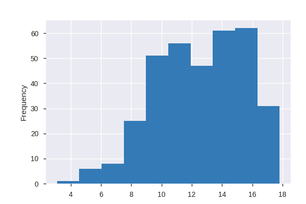

**Common Values**

| Value | Count | Frequency (%) |  |
| --- | --- | --- | --- |
| 15.0 | 16 | 4.0% |  |
| 10.9 | 8 | 2.0% |  |
| 13.0 | 7 | 1.8% |  |
| 13.6 | 7 | 1.8% |  |
| 9.8 | 7 | 1.8% |  |
| 11.1 | 7 | 1.8% |  |
| 12.0 | 6 | 1.5% |  |
| 13.9 | 6 | 1.5% |  |
| 11.3 | 6 | 1.5% |  |
| 10.3 | 6 | 1.5% |  |
| Other values (105) | 272 | 68.0% |  |
| (Missing) | 52 | 13.0% |  |

**Extreme Values**

Minimum 5 values

| Value | Count | Frequency (%) |  |
| --- | --- | --- | --- |
| 3.1 | 1 | 0.2% |  |
| 4.8 | 1 | 0.2% |  |
| 5.5 | 1 | 0.2% |  |
| 5.6 | 1 | 0.2% |  |
| 5.8 | 1 | 0.2% |  |

Maximum 5 values

| Value | Count | Frequency (%) |  |
| --- | --- | --- | --- |
| 17.4 | 2 | 0.5% |  |
| 17.5 | 1 | 0.2% |  |
| 17.6 | 1 | 0.2% |  |
| 17.7 | 1 | 0.2% |  |
| 17.8 | 3 | 0.8% |  |

htn  
Categorical

| Distinct count | 3 |
| --- | --- |
| Unique (%) | 0.8% |
| Missing (%) | 0.5% |
| Missing (n) | 2 |

| no | 251 |
| --- | --- |
| yes | 147 |
| (Missing) | 2 |

Toggle details

| Value | Count | Frequency (%) |  |
| --- | --- | --- | --- |
| no | 251 | 62.7% |  |
| yes | 147 | 36.8% |  |
| (Missing) | 2 | 0.5% |  |

pc  
Categorical

| Distinct count | 3 |
| --- | --- |
| Unique (%) | 0.8% |
| Missing (%) | 16.2% |
| Missing (n) | 65 |

| normal | 259 |
| --- | --- |
| abnormal | 76 |
| (Missing) | 65 |

Toggle details

| Value | Count | Frequency (%) |  |
| --- | --- | --- | --- |
| normal | 259 | 64.8% |  |
| abnormal | 76 | 19.0% |  |
| (Missing) | 65 | 16.2% |  |

pcc  
Categorical

| Distinct count | 3 |
| --- | --- |
| Unique (%) | 0.8% |
| Missing (%) | 1.0% |
| Missing (n) | 4 |

| notpresent | 354 |
| --- | --- |
| present | 42 |
| (Missing) | 4 |

Toggle details

| Value | Count | Frequency (%) |  |
| --- | --- | --- | --- |
| notpresent | 354 | 88.5% |  |
| present | 42 | 10.5% |  |
| (Missing) | 4 | 1.0% |  |

pcv  
Categorical

| Distinct count | 45 |
| --- | --- |
| Unique (%) | 11.2% |
| Missing (%) | 17.5% |
| Missing (n) | 70 |

| 41 | 21 |
| --- | --- |
| 52 | 21 |
| 48 | 19 |
| Other values (41) | 269 |
| (Missing) | 70 |

Toggle details

| Value | Count | Frequency (%) |  |
| --- | --- | --- | --- |
| 41 | 21 | 5.2% |  |
| 52 | 21 | 5.2% |  |
| 48 | 19 | 4.8% |  |
| 44 | 19 | 4.8% |  |
| 40 | 16 | 4.0% |  |
| 43 | 14 | 3.5% |  |
| 45 | 13 | 3.2% |  |
| 42 | 13 | 3.2% |  |
| 36 | 12 | 3.0% |  |
| 28 | 12 | 3.0% |  |
| Other values (34) | 170 | 42.5% |  |
| (Missing) | 70 | 17.5% |  |

pe  
Categorical

| Distinct count | 3 |
| --- | --- |
| Unique (%) | 0.8% |
| Missing (%) | 0.2% |
| Missing (n) | 1 |

| no | 323 |
| --- | --- |
| yes | 76 |
| (Missing) | 1 |

Toggle details

| Value | Count | Frequency (%) |  |
| --- | --- | --- | --- |
| no | 323 | 80.8% |  |
| yes | 76 | 19.0% |  |
| (Missing) | 1 | 0.2% |  |

pot  
Numeric

| Distinct count | 41 |
| --- | --- |
| Unique (%) | 10.2% |
| Missing (%) | 22.0% |
| Missing (n) | 88 |
| Infinite (%) | 0.0% |
| Infinite (n) | 0 |

| Mean | 4.6272 |
| --- | --- |
| Minimum | 2.5 |
| Maximum | 47 |
| Zeros (%) | 0.0% |

Toggle details

**Statistics**

Quantile statistics

| Minimum | 2.5 |
| --- | --- |
| 5-th percentile | 3.4 |
| Q1 | 3.8 |
| Median | 4.4 |
| Q3 | 4.9 |
| 95-th percentile | 5.7 |
| Maximum | 47 |
| Range | 44.5 |
| Interquartile range | 1.1 |

Descriptive statistics

| Standard deviation | 3.1939 |
| --- | --- |
| Coef of variation | 0.69024 |
| Kurtosis | 142.51 |
| Mean | 4.6272 |
| MAD | 0.87735 |
| Skewness | 11.583 |
| Sum | 1443.7 |
| Variance | 10.201 |
| Memory size | 6.2 KiB |

**Histogram**

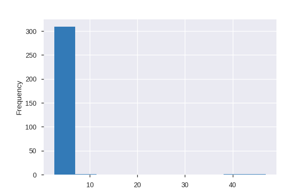

**Common Values**

| Value | Count | Frequency (%) |  |
| --- | --- | --- | --- |
| 5.0 | 30 | 7.5% |  |
| 3.5 | 30 | 7.5% |  |
| 4.9 | 27 | 6.8% |  |
| 4.7 | 17 | 4.2% |  |
| 4.8 | 16 | 4.0% |  |
| 4.4 | 14 | 3.5% |  |
| 3.8 | 14 | 3.5% |  |
| 4.2 | 14 | 3.5% |  |
| 4.1 | 14 | 3.5% |  |
| 3.9 | 14 | 3.5% |  |
| Other values (30) | 122 | 30.5% |  |
| (Missing) | 88 | 22.0% |  |

**Extreme Values**

Minimum 5 values

| Value | Count | Frequency (%) |  |
| --- | --- | --- | --- |
| 2.5 | 2 | 0.5% |  |
| 2.7 | 1 | 0.2% |  |
| 2.8 | 1 | 0.2% |  |
| 2.9 | 3 | 0.8% |  |
| 3.0 | 2 | 0.5% |  |

Maximum 5 values

| Value | Count | Frequency (%) |  |
| --- | --- | --- | --- |
| 6.5 | 2 | 0.5% |  |
| 6.6 | 1 | 0.2% |  |
| 7.6 | 1 | 0.2% |  |
| 39.0 | 1 | 0.2% |  |
| 47.0 | 1 | 0.2% |  |

rbc  
Categorical

| Distinct count | 3 |
| --- | --- |
| Unique (%) | 0.8% |
| Missing (%) | 38.0% |
| Missing (n) | 152 |

| normal | 201 |
| --- | --- |
| abnormal | 47 |
| (Missing) | 152 |

Toggle details

| Value | Count | Frequency (%) |  |
| --- | --- | --- | --- |
| normal | 201 | 50.2% |  |
| abnormal | 47 | 11.8% |  |
| (Missing) | 152 | 38.0% |  |

rc  
Categorical

| Distinct count | 50 |
| --- | --- |
| Unique (%) | 12.5% |
| Missing (%) | 32.5% |
| Missing (n) | 130 |

| 5.2 | 18 |
| --- | --- |
| 4.5 | 16 |
| 4.9 | 14 |
| Other values (46) | 222 |
| (Missing) | 130 |

Toggle details

| Value | Count | Frequency (%) |  |
| --- | --- | --- | --- |
| 5.2 | 18 | 4.5% |  |
| 4.5 | 16 | 4.0% |  |
| 4.9 | 14 | 3.5% |  |
| 4.7 | 11 | 2.8% |  |
| 4.8 | 10 | 2.5% |  |
| 3.9 | 10 | 2.5% |  |
| 3.4 | 9 | 2.2% |  |
| 4.6 | 9 | 2.2% |  |
| 5.5 | 8 | 2.0% |  |
| 6.1 | 8 | 2.0% |  |
| Other values (39) | 157 | 39.2% |  |
| (Missing) | 130 | 32.5% |  |

sc  
Numeric

| Distinct count | 85 |
| --- | --- |
| Unique (%) | 21.2% |
| Missing (%) | 4.2% |
| Missing (n) | 17 |
| Infinite (%) | 0.0% |
| Infinite (n) | 0 |

| Mean | 3.0725 |
| --- | --- |
| Minimum | 0.4 |
| Maximum | 76 |
| Zeros (%) | 0.0% |

Toggle details

**Statistics**

Quantile statistics

| Minimum | 0.4 |
| --- | --- |
| 5-th percentile | 0.5 |
| Q1 | 0.9 |
| Median | 1.3 |
| Q3 | 2.8 |
| 95-th percentile | 11.89 |
| Maximum | 76 |
| Range | 75.6 |
| Interquartile range | 1.9 |

Descriptive statistics

| Standard deviation | 5.7411 |
| --- | --- |
| Coef of variation | 1.8686 |
| Kurtosis | 79.304 |
| Mean | 3.0725 |
| MAD | 2.7529 |
| Skewness | 7.5095 |
| Sum | 1176.8 |
| Variance | 32.961 |
| Memory size | 6.2 KiB |

**Histogram**

[figure not shown]

**Common Values**

| Value | Count | Frequency (%) |  |
| --- | --- | --- | --- |
| 1.2 | 40 | 10.0% |  |
| 1.1 | 24 | 6.0% |  |
| 1.0 | 23 | 5.8% |  |
| 0.5 | 23 | 5.8% |  |
| 0.7 | 22 | 5.5% |  |
| 0.9 | 22 | 5.5% |  |
| 0.6 | 18 | 4.5% |  |
| 0.8 | 17 | 4.2% |  |
| 2.2 | 10 | 2.5% |  |
| 1.7 | 9 | 2.2% |  |
| Other values (74) | 175 | 43.8% |  |
| (Missing) | 17 | 4.2% |  |

**Extreme Values**

Minimum 5 values

| Value | Count | Frequency (%) |  |
| --- | --- | --- | --- |
| 0.4 | 1 | 0.2% |  |
| 0.5 | 23 | 5.8% |  |
| 0.6 | 18 | 4.5% |  |
| 0.7 | 22 | 5.5% |  |
| 0.8 | 17 | 4.2% |  |

Maximum 5 values

| Value | Count | Frequency (%) |  |
| --- | --- | --- | --- |
| 18.1 | 1 | 0.2% |  |
| 24.0 | 1 | 0.2% |  |
| 32.0 | 1 | 0.2% |  |
| 48.1 | 1 | 0.2% |  |
| 76.0 | 1 | 0.2% |  |

sg  
Numeric

| Distinct count | 6 |
| --- | --- |
| Unique (%) | 1.5% |
| Missing (%) | 11.8% |
| Missing (n) | 47 |
| Infinite (%) | 0.0% |
| Infinite (n) | 0 |

| Mean | 1.0174 |
| --- | --- |
| Minimum | 1.005 |
| Maximum | 1.025 |
| Zeros (%) | 0.0% |

Toggle details

**Statistics**

Quantile statistics

| Minimum | 1.005 |
| --- | --- |
| 5-th percentile | 1.01 |
| Q1 | 1.01 |
| Median | 1.02 |
| Q3 | 1.02 |
| 95-th percentile | 1.025 |
| Maximum | 1.025 |
| Range | 0.02 |
| Interquartile range | 0.01 |

Descriptive statistics

| Standard deviation | 0.0057166 |
| --- | --- |
| Coef of variation | 0.0056188 |
| Kurtosis | -1.1444 |
| Mean | 1.0174 |
| MAD | 0.0050409 |
| Skewness | -0.17244 |
| Sum | 359.14 |
| Variance | 3.268e-05 |
| Memory size | 6.2 KiB |

**Histogram**

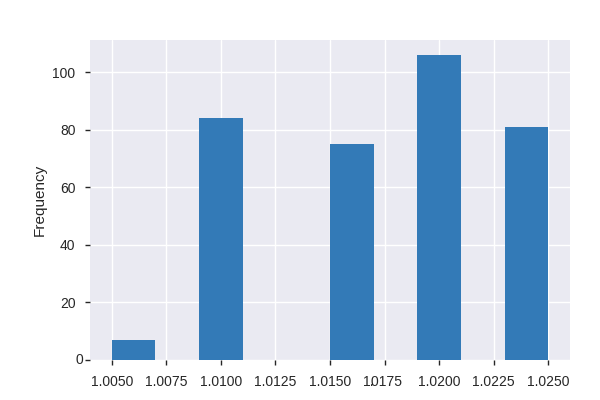

**Common Values**

| Value | Count | Frequency (%) |  |
| --- | --- | --- | --- |
| 1.02 | 106 | 26.5% |  |
| 1.01 | 84 | 21.0% |  |
| 1.025 | 81 | 20.2% |  |
| 1.015 | 75 | 18.8% |  |
| 1.005 | 7 | 1.8% |  |
| (Missing) | 47 | 11.8% |  |

**Extreme Values**

Minimum 5 values

| Value | Count | Frequency (%) |  |
| --- | --- | --- | --- |
| 1.005 | 7 | 1.8% |  |
| 1.01 | 84 | 21.0% |  |
| 1.015 | 75 | 18.8% |  |
| 1.02 | 106 | 26.5% |  |
| 1.025 | 81 | 20.2% |  |

Maximum 5 values

| Value | Count | Frequency (%) |  |
| --- | --- | --- | --- |
| 1.005 | 7 | 1.8% |  |
| 1.01 | 84 | 21.0% |  |
| 1.015 | 75 | 18.8% |  |
| 1.02 | 106 | 26.5% |  |
| 1.025 | 81 | 20.2% |  |

sod  
Numeric

| Distinct count | 35 |
| --- | --- |
| Unique (%) | 8.8% |
| Missing (%) | 21.8% |
| Missing (n) | 87 |
| Infinite (%) | 0.0% |
| Infinite (n) | 0 |

| Mean | 137.53 |
| --- | --- |
| Minimum | 4.5 |
| Maximum | 163 |
| Zeros (%) | 0.0% |

Toggle details

**Statistics**

Quantile statistics

| Minimum | 4.5 |
| --- | --- |
| 5-th percentile | 125 |
| Q1 | 135 |
| Median | 138 |
| Q3 | 142 |
| 95-th percentile | 150 |
| Maximum | 163 |
| Range | 158.5 |
| Interquartile range | 7 |

Descriptive statistics

| Standard deviation | 10.409 |
| --- | --- |
| Coef of variation | 0.075684 |
| Kurtosis | 85.534 |
| Mean | 137.53 |
| MAD | 5.5944 |
| Skewness | -6.9966 |
| Sum | 43046 |
| Variance | 108.34 |
| Memory size | 6.2 KiB |

**Histogram**

[figure not shown]

**Common Values**

| Value | Count | Frequency (%) |  |
| --- | --- | --- | --- |
| 135.0 | 40 | 10.0% |  |
| 140.0 | 25 | 6.2% |  |
| 141.0 | 22 | 5.5% |  |
| 139.0 | 21 | 5.2% |  |
| 142.0 | 20 | 5.0% |  |
| 138.0 | 20 | 5.0% |  |
| 137.0 | 19 | 4.8% |  |
| 150.0 | 17 | 4.2% |  |
| 136.0 | 17 | 4.2% |  |
| 147.0 | 13 | 3.2% |  |
| Other values (24) | 99 | 24.8% |  |
| (Missing) | 87 | 21.8% |  |

**Extreme Values**

Minimum 5 values

| Value | Count | Frequency (%) |  |
| --- | --- | --- | --- |
| 4.5 | 1 | 0.2% |  |
| 104.0 | 1 | 0.2% |  |
| 111.0 | 1 | 0.2% |  |
| 113.0 | 2 | 0.5% |  |
| 114.0 | 2 | 0.5% |  |

Maximum 5 values

| Value | Count | Frequency (%) |  |
| --- | --- | --- | --- |
| 145.0 | 11 | 2.8% |  |
| 146.0 | 10 | 2.5% |  |
| 147.0 | 13 | 3.2% |  |
| 150.0 | 17 | 4.2% |  |
| 163.0 | 1 | 0.2% |  |

su  
Numeric

| Distinct count | 7 |
| --- | --- |
| Unique (%) | 1.8% |
| Missing (%) | 12.3% |
| Missing (n) | 49 |
| Infinite (%) | 0.0% |
| Infinite (n) | 0 |

| Mean | 0.45014 |
| --- | --- |
| Minimum | 0 |
| Maximum | 5 |
| Zeros (%) | 72.5% |

Toggle details

**Statistics**

Quantile statistics

| Minimum | 0 |
| --- | --- |
| 5-th percentile | 0 |
| Q1 | 0 |
| Median | 0 |
| Q3 | 0 |
| 95-th percentile | 3 |
| Maximum | 5 |
| Range | 5 |
| Interquartile range | 0 |

Descriptive statistics

| Standard deviation | 1.0992 |
| --- | --- |
| Coef of variation | 2.4419 |
| Kurtosis | 5.0553 |
| Mean | 0.45014 |
| MAD | 0.74383 |
| Skewness | 2.4643 |
| Sum | 158 |
| Variance | 1.2082 |
| Memory size | 6.2 KiB |

**Histogram**

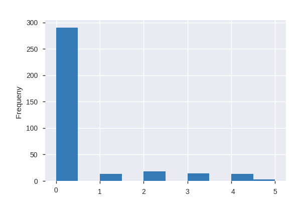

**Common Values**

| Value | Count | Frequency (%) |  |
| --- | --- | --- | --- |
| 0.0 | 290 | 72.5% |  |
| 2.0 | 18 | 4.5% |  |
| 3.0 | 14 | 3.5% |  |
| 1.0 | 13 | 3.2% |  |
| 4.0 | 13 | 3.2% |  |
| 5.0 | 3 | 0.8% |  |
| (Missing) | 49 | 12.2% |  |

**Extreme Values**

Minimum 5 values

| Value | Count | Frequency (%) |  |
| --- | --- | --- | --- |
| 0.0 | 290 | 72.5% |  |
| 1.0 | 13 | 3.2% |  |
| 2.0 | 18 | 4.5% |  |
| 3.0 | 14 | 3.5% |  |
| 4.0 | 13 | 3.2% |  |

Maximum 5 values

| Value | Count | Frequency (%) |  |
| --- | --- | --- | --- |
| 1.0 | 13 | 3.2% |  |
| 2.0 | 18 | 4.5% |  |
| 3.0 | 14 | 3.5% |  |
| 4.0 | 13 | 3.2% |  |
| 5.0 | 3 | 0.8% |  |

wc  
Categorical

| Distinct count | 93 |
| --- | --- |
| Unique (%) | 23.2% |
| Missing (%) | 26.2% |
| Missing (n) | 105 |

| 9800 | 11 |
| --- | --- |
| 6700 | 10 |
| 7200 | 9 |
| Other values (89) | 265 |
| (Missing) | 105 |

Toggle details

| Value | Count | Frequency (%) |  |
| --- | --- | --- | --- |
| 9800 | 11 | 2.8% |  |
| 6700 | 10 | 2.5% |  |
| 7200 | 9 | 2.2% |  |
| 9200 | 9 | 2.2% |  |
| 9600 | 9 | 2.2% |  |
| 6900 | 8 | 2.0% |  |
| 11000 | 8 | 2.0% |  |
| 5800 | 8 | 2.0% |  |
| 7800 | 7 | 1.8% |  |
| 9400 | 7 | 1.8% |  |
| Other values (82) | 209 | 52.2% |  |
| (Missing) | 105 | 26.2% |  |

Correlations

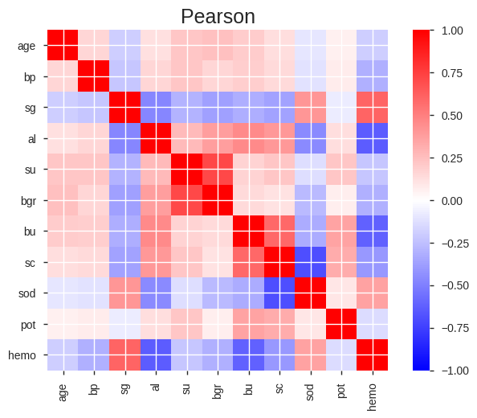

[1 more figures not shown]

Sample

| id | age | bp | sg | al | su | rbc | pc | pcc | ba | bgr | bu | sc | sod | pot | hemo | pcv | wc | rc | htn | dm | cad | appet | pe | ane | classification |
| --- | --- | --- | --- | --- | --- | --- | --- | --- | --- | --- | --- | --- | --- | --- | --- | --- | --- | --- | --- | --- | --- | --- | --- | --- | --- |
| 0 | 48.0 | 80.0 | 1.020 | 1.0 | 0.0 | NaN | normal | notpresent | notpresent | 121.0 | 36.0 | 1.2 | NaN | NaN | 15.4 | 44 | 7800 | 5.2 | yes | yes | no | good | no | no | ckd |
| 1 | 7.0 | 50.0 | 1.020 | 4.0 | 0.0 | NaN | normal | notpresent | notpresent | NaN | 18.0 | 0.8 | NaN | NaN | 11.3 | 38 | 6000 | NaN | no | no | no | good | no | no | ckd |
| 2 | 62.0 | 80.0 | 1.010 | 2.0 | 3.0 | normal | normal | notpresent | notpresent | 423.0 | 53.0 | 1.8 | NaN | NaN | 9.6 | 31 | 7500 | NaN | no | yes | no | poor | no | yes | ckd |
| 3 | 48.0 | 70.0 | 1.005 | 4.0 | 0.0 | normal | abnormal | present | notpresent | 117.0 | 56.0 | 3.8 | 111.0 | 2.5 | 11.2 | 32 | 6700 | 3.9 | yes | no | no | poor | yes | yes | ckd |
| 4 | 51.0 | 80.0 | 1.010 | 2.0 | 0.0 | normal | normal | notpresent | notpresent | 106.0 | 26.0 | 1.4 | NaN | NaN | 11.6 | 35 | 7300 | 4.6 | no | no | no | good | no | no | ckd |

```python
# Looking at variables interractively
profile = ProfileReport(df)

profile
```

```python
# looking for the number of missing observations
# In the code below a boolean is being tried on each observation asking if the observation is missing or not
# then add all instances of NaN(Not a number)
missing_values = df.isnull().sum()

# calculating the percentage of missing values in the dataframe
# simply taking the sum of the values we got above dividing by the no of observations in the df
# you could use len(df) instead df.index.size
missing_count_pct = ((missing_values / df.index.size) * 100)

# see how many observations are missing
print(missing_count_pct)
```

```
age                2.25
bp                 3.00
sg                11.75
al                11.50
su                12.25
rbc               38.00
pc                16.25
pcc                1.00
ba                 1.00
bgr               11.00
bu                 4.75
sc                 4.25
sod               21.75
pot               22.00
hemo              13.00
pcv               17.50
wc                26.25
rc                32.50
htn                0.50
dm                 0.50
cad                0.50
appet              0.25
pe                 0.25
ane                0.25
classification     0.00
dtype: float64
```

```python
# take the missing count percentage and use boolean mask to filter out columns
# whose observation threshold is greater than 25 percent
columns_to_drop = missing_count_pct[missing_count_pct > 25].index

# remove columns that meet that threshold and save result in column df_dropped
df_dropped = df.drop(columns_to_drop, axis=1)
```

```python
# number of columns remaining after filtering
df.columns.size - df_dropped.columns.size

# only three columns are lost
```

```
3
```

I really hate losing a few columns. I won't throw everything away. But, I will keep these columns while we are doing predictive modelling use the different variants of the datasets and see if there will be any boost in results. In the meantime, let's look at the code book to come up with a hypothesis to find out which columns are the most important and converting the types of each column to another format that will speed up computation during training.

```python
# look at the code book on kaggle and write which columns could be useful here
```

According to the original site where we found data [here.](https://archive.ics.uci.edu/ml/datasets/Chronic_Kidney_Disease). I found the identity of the columns rather what the columns mean. I'll put a star on the columns i think are important from my background in medical laboratory science. Then the second run through this notebook we could explore only the columns i think are important and lastly use a technique called singular value decomposition to figure out which ones are the most important.

age - age

bp - blood pressure *

sg - specific gravity *

al - albumin *

su - sugar *

rbc - red blood cells *

pc - pus cell*

pcc - pus cell clumps *

ba - bacteria*

bgr - blood glucose random

bu - blood urea*

sc - serum creatinine

sod - sodium

pot - potassium

hemo - hemoglobin*

pcv - packed cell volume

wc - white blood cell count*

rc - red blood cell count*

htn - hypertension*

dm - diabetes mellitus*

cad - coronary artery disease*

appet - appetite*

pe - pedal edema*

ane - anemia*

class - class*

```python
# checking the types of the column to figure out the best next steps of conversion of data types
df.dtypes
```

```
age               float64
bp                float64
sg                float64
al                float64
su                float64
rbc                object
pc                 object
pcc                object
ba                 object
bgr               float64
bu                float64
sc                float64
sod               float64
pot               float64
hemo              float64
pcv                object
wc                 object
rc                 object
htn                object
dm                 object
cad                object
appet              object
pe                 object
ane                object
classification     object
dtype: object
```

Review the columns from the original codebook to determine the datatypes then make a schema which we can follow as i import the dataset

```python
# fix the columns to be of the categorical type
# if the value is missing replace the NA with the word miss
constant_imputer = SimpleImputer(strategy="constant", fill_value = "miss")

# apply it to categorical columns
df[["rbc"]] = constant_imputer.fit_transform(df[["rbc"]])
df[["pcc"]] = constant_imputer.fit_transform(df[["pcc"]])

# converting the types to be categorical
# Go ahead and use a function here
df['rbc'] = df['rbc'].astype("category")
df['pc'] = df['pc'].astype("category")
df["pcc"] = df['pcc'].astype("category")
df['ba'] = df['ba'].astype("category")
df['appet'] = df['appet'].astype("category")
df['pe'] = df['pe'].astype("category")
df['ane'] = df['ane'].astype("category")
df['classification'] = df['classification'].astype("category")
df['htn'] = df['htn'].astype("category")
df['dm'] = df['dm'].astype("category")
df['cad'] = df['cad'].astype("category")


# confirm the dtypes now
df.dtypes
```

```
age                float64
bp                 float64
sg                 float64
al                 float64
su                 float64
rbc               category
pc                category
pcc               category
ba                category
bgr                float64
bu                 float64
sc                 float64
sod                float64
pot                float64
hemo               float64
pcv                 object
wc                  object
rc                  object
htn               category
dm                category
cad               category
appet             category
pe                category
ane               category
classification    category
dtype: object
```

```python
# seeing the columns in list form thinking mode
df.columns
```

```
Index(['age', 'bp', 'sg', 'al', 'su', 'rbc', 'pc', 'pcc', 'ba', 'bgr', 'bu',
       'sc', 'sod', 'pot', 'hemo', 'pcv', 'wc', 'rc', 'htn', 'dm', 'cad',
       'appet', 'pe', 'ane', 'classification'],
      dtype='object')
```

```python
# make a copy of the whole dataset
df_copy = df.copy()

# remove the target column for the other uses in the next steps
#df = df.drop("classification", axis = 1)
```

```python
# using a boolean to figure out which columns are of type object and numeric to do other preprocessing
# in the workflow
object_columns = df.dtypes == "object"
numeric_columns = df.dtypes == "float64"
category_columns = df.dtypes == "category"
```

```python
# use regular expressions to fix it and this is supposed to be one of the first steps after df.dtypes command. If it's categorical
# you can replace it with anything you want here I use -999 to replace the data entries the tab character to flag them as outliers.
# I change the dtypes so to 32 bit to save memory

df['pcv'] = df['pcv'].replace("\t?",-999).fillna(0).astype("int32") # use  str.replace on column to something meaningful
df['wc'] = df['wc'].replace("\t?", -999).fillna(0).astype("int32") # use  str.replace on column to something meaningful
df['rc'] = df['rc'].replace("\t?", -999).fillna(0).astype("float32") # use  str.replace on column to something meaningful

# exploring another imputation strategy that uses the median
# mean_imputer = SimpleImputer(strategy="median")
# df["pcv"] = mean_imputer.fit_transform(df["pcv"])
# df["wc"] = mean_imputer.fit_transform(df["wc"])
# df["rc"] = mean_imputer.fit_transform(df["rc"])
```

```python
# write code to extract columns of the type object and numeric
# Make a boolean mask for categorical columns
cat_mask_obj = (df.dtypes == "object") | (df.dtypes == "category")

# Get list of categorical column names
cat_mask_object = df.columns[cat_mask_obj].tolist()

# now for numerical columns
# anything that was parsed as float64 is numeric: make a boolean mask for that
cat_mask_numeric = (df.dtypes == "float64")
cat_mask_numeric = df.columns[cat_mask_numeric].tolist()

# see the result in a combined list: to the left categorical and the right we have numeric columns
print(cat_mask_object, "\n", cat_mask_numeric)
```

```
['rbc', 'pc', 'pcc', 'ba', 'htn', 'dm', 'cad', 'appet', 'pe', 'ane', 'classification']
 ['age', 'bp', 'sg', 'al', 'su', 'bgr', 'bu', 'sc', 'sod', 'pot', 'hemo']
```

```python
# convert all instances of the float 64 to float 32 to speed up computation in the subsequent steps
# remove all the missing values and make sure that they are all numeric
numeric_columns_float32 = df[cat_mask_numeric].astype("float32").fillna(0)
```

```python
#it's worked
numeric_columns_float32.dtypes
```

```
age     float32
bp      float32
sg      float32
al      float32
su      float32
bgr     float32
bu      float32
sc      float32
sod     float32
pot     float32
hemo    float32
dtype: object
```

```python
# Task: split the category columns and object columns to the right type
# you can import the dataset to have the right types too upon import
# you can do this the next time you have time to continue working on this add it as comment though
```

```python
# it makes sense that they are some individuals who were not sampled therefore filling the whole dataset with NAs makes sense
# these two columns have data entry problems
# use regular expressions to fix it and this is supposed to be one of the first steps after df.dtypes command. If it's categorical
# you can replace it with anything you want
#df['pcv'] = df['pcv'].fillna(0, inplace = True)
#df['rc'] = df['rc'].fillna(0, inplace = True)
#df['wc'] = df['wc'].fillna(0, inplace = True)
```

```python
# finding the number of null or NA values in the columns
pd.isnull(df).sum()
```

```
age                9
bp                12
sg                47
al                46
su                49
rbc                0
pc                65
pcc                0
ba                 4
bgr               44
bu                19
sc                17
sod               87
pot               88
hemo              52
pcv                0
wc                 0
rc                 0
htn                2
dm                 2
cad                2
appet              1
pe                 1
ane                1
classification     0
dtype: int64
```

```python
# checking the dtypes once more
df.dtypes
```

```
age                float64
bp                 float64
sg                 float64
al                 float64
su                 float64
rbc               category
pc                category
pcc               category
ba                category
bgr                float64
bu                 float64
sc                 float64
sod                float64
pot                float64
hemo               float64
pcv                  int32
wc                   int32
rc                 float32
htn               category
dm                category
cad               category
appet             category
pe                category
ane               category
classification    category
dtype: object
```

```python
# concatentate the numeric columns with the category columns to build the full dataset and then X and Y
# remove
df[cat_mask_object] = constant_imputer.fit_transform(df[cat_mask_object])
```

```python
# check for missing values
print(df[cat_mask_object].isnull().sum())
print("*" * 100)
print(numeric_columns_float32.isnull().sum())
```

```
rbc               0
pc                0
pcc               0
ba                0
htn               0
dm                0
cad               0
appet             0
pe                0
ane               0
classification    0
dtype: int64
age     0
bp      0
sg      0
al      0
su      0
bgr     0
bu      0
sc      0
sod     0
pot     0
hemo    0
dtype: int64
```

```python
# bring the columns together with pd.concat
df_clean = pd.concat([numeric_columns_float32, df[cat_mask_object]], axis = 1)

# check the shape of the columns
df_clean.shape
```

```
(400, 22)
```

```python
# just see the first 10 observations
df_clean.head(10)
# HTML(df_clean.to_html()) see the whole dataframe in HTML format
```

| id | age | bp | sg | al | su | bgr | bu | sc | sod | pot | hemo | rbc | pc | pcc | ba | htn | dm | cad | appet | pe | ane | classification |
| --- | --- | --- | --- | --- | --- | --- | --- | --- | --- | --- | --- | --- | --- | --- | --- | --- | --- | --- | --- | --- | --- | --- |
| 0 | 48.0 | 80.0 | 1.020 | 1.0 | 0.0 | 121.0 | 36.0 | 1.2 | 0.0 | 0.0 | 15.4 | miss | normal | notpresent | notpresent | yes | yes | no | good | no | no | ckd |
| 1 | 7.0 | 50.0 | 1.020 | 4.0 | 0.0 | 0.0 | 18.0 | 0.8 | 0.0 | 0.0 | 11.3 | miss | normal | notpresent | notpresent | no | no | no | good | no | no | ckd |
| 2 | 62.0 | 80.0 | 1.010 | 2.0 | 3.0 | 423.0 | 53.0 | 1.8 | 0.0 | 0.0 | 9.6 | normal | normal | notpresent | notpresent | no | yes | no | poor | no | yes | ckd |
| 3 | 48.0 | 70.0 | 1.005 | 4.0 | 0.0 | 117.0 | 56.0 | 3.8 | 111.0 | 2.5 | 11.2 | normal | abnormal | present | notpresent | yes | no | no | poor | yes | yes | ckd |
| 4 | 51.0 | 80.0 | 1.010 | 2.0 | 0.0 | 106.0 | 26.0 | 1.4 | 0.0 | 0.0 | 11.6 | normal | normal | notpresent | notpresent | no | no | no | good | no | no | ckd |
| 5 | 60.0 | 90.0 | 1.015 | 3.0 | 0.0 | 74.0 | 25.0 | 1.1 | 142.0 | 3.2 | 12.2 | miss | miss | notpresent | notpresent | yes | yes | no | good | yes | no | ckd |
| 6 | 68.0 | 70.0 | 1.010 | 0.0 | 0.0 | 100.0 | 54.0 | 24.0 | 104.0 | 4.0 | 12.4 | miss | normal | notpresent | notpresent | no | no | no | good | no | no | ckd |
| 7 | 24.0 | 0.0 | 1.015 | 2.0 | 4.0 | 410.0 | 31.0 | 1.1 | 0.0 | 0.0 | 12.4 | normal | abnormal | notpresent | notpresent | no | yes | no | good | yes | no | ckd |
| 8 | 52.0 | 100.0 | 1.015 | 3.0 | 0.0 | 138.0 | 60.0 | 1.9 | 0.0 | 0.0 | 10.8 | normal | abnormal | present | notpresent | yes | yes | no | good | no | yes | ckd |
| 9 | 53.0 | 90.0 | 1.020 | 2.0 | 0.0 | 70.0 | 107.0 | 7.2 | 114.0 | 3.7 | 9.5 | abnormal | abnormal | present | notpresent | yes | yes | no | poor | no | yes | ckd |

```python
# now see the bottom 10
df_clean.tail(10)
```

| id | age | bp | sg | al | su | bgr | bu | sc | sod | pot | hemo | rbc | pc | pcc | ba | htn | dm | cad | appet | pe | ane | classification |
| --- | --- | --- | --- | --- | --- | --- | --- | --- | --- | --- | --- | --- | --- | --- | --- | --- | --- | --- | --- | --- | --- | --- |
| 390 | 52.0 | 80.0 | 1.025 | 0.0 | 0.0 | 99.0 | 25.0 | 0.8 | 135.0 | 3.7 | 15.0 | normal | normal | notpresent | notpresent | no | no | no | good | no | no | notckd |
| 391 | 36.0 | 80.0 | 1.025 | 0.0 | 0.0 | 85.0 | 16.0 | 1.1 | 142.0 | 4.1 | 15.6 | normal | normal | notpresent | notpresent | no | no | no | good | no | no | notckd |
| 392 | 57.0 | 80.0 | 1.020 | 0.0 | 0.0 | 133.0 | 48.0 | 1.2 | 147.0 | 4.3 | 14.8 | normal | normal | notpresent | notpresent | no | no | no | good | no | no | notckd |
| 393 | 43.0 | 60.0 | 1.025 | 0.0 | 0.0 | 117.0 | 45.0 | 0.7 | 141.0 | 4.4 | 13.0 | normal | normal | notpresent | notpresent | no | no | no | good | no | no | notckd |
| 394 | 50.0 | 80.0 | 1.020 | 0.0 | 0.0 | 137.0 | 46.0 | 0.8 | 139.0 | 5.0 | 14.1 | normal | normal | notpresent | notpresent | no | no | no | good | no | no | notckd |
| 395 | 55.0 | 80.0 | 1.020 | 0.0 | 0.0 | 140.0 | 49.0 | 0.5 | 150.0 | 4.9 | 15.7 | normal | normal | notpresent | notpresent | no | no | no | good | no | no | notckd |
| 396 | 42.0 | 70.0 | 1.025 | 0.0 | 0.0 | 75.0 | 31.0 | 1.2 | 141.0 | 3.5 | 16.5 | normal | normal | notpresent | notpresent | no | no | no | good | no | no | notckd |
| 397 | 12.0 | 80.0 | 1.020 | 0.0 | 0.0 | 100.0 | 26.0 | 0.6 | 137.0 | 4.4 | 15.8 | normal | normal | notpresent | notpresent | no | no | no | good | no | no | notckd |
| 398 | 17.0 | 60.0 | 1.025 | 0.0 | 0.0 | 114.0 | 50.0 | 1.0 | 135.0 | 4.9 | 14.2 | normal | normal | notpresent | notpresent | no | no | no | good | no | no | notckd |
| 399 | 58.0 | 80.0 | 1.025 | 0.0 | 0.0 | 131.0 | 18.0 | 1.1 | 141.0 | 3.5 | 15.8 | normal | normal | notpresent | notpresent | no | no | no | good | no | no | notckd |

```python
HTML(df.to_html()) # just looking for something I may have missed in the pandas profiling
```

| id | age | bp | sg | al | su | rbc | pc | pcc | ba | bgr | bu | sc | sod | pot | hemo | pcv | wc | rc | htn | dm | cad | appet | pe | ane | classification |
| --- | --- | --- | --- | --- | --- | --- | --- | --- | --- | --- | --- | --- | --- | --- | --- | --- | --- | --- | --- | --- | --- | --- | --- | --- | --- |
| 0 | 48.0 | 80.0 | 1.020 | 1.0 | 0.0 | miss | normal | notpresent | notpresent | 121.0 | 36.0 | 1.20 | NaN | NaN | 15.4 | 44 | 7800 | 5.2 | yes | yes | no | good | no | no | ckd |
| 1 | 7.0 | 50.0 | 1.020 | 4.0 | 0.0 | miss | normal | notpresent | notpresent | NaN | 18.0 | 0.80 | NaN | NaN | 11.3 | 38 | 6000 | 0.0 | no | no | no | good | no | no | ckd |
| 2 | 62.0 | 80.0 | 1.010 | 2.0 | 3.0 | normal | normal | notpresent | notpresent | 423.0 | 53.0 | 1.80 | NaN | NaN | 9.6 | 31 | 7500 | 0.0 | no | yes | no | poor | no | yes | ckd |
| 3 | 48.0 | 70.0 | 1.005 | 4.0 | 0.0 | normal | abnormal | present | notpresent | 117.0 | 56.0 | 3.80 | 111.0 | 2.5 | 11.2 | 32 | 6700 | 3.9 | yes | no | no | poor | yes | yes | ckd |
| 4 | 51.0 | 80.0 | 1.010 | 2.0 | 0.0 | normal | normal | notpresent | notpresent | 106.0 | 26.0 | 1.40 | NaN | NaN | 11.6 | 35 | 7300 | 4.6 | no | no | no | good | no | no | ckd |
| 5 | 60.0 | 90.0 | 1.015 | 3.0 | 0.0 | miss | miss | notpresent | notpresent | 74.0 | 25.0 | 1.10 | 142.0 | 3.2 | 12.2 | 39 | 7800 | 4.4 | yes | yes | no | good | yes | no | ckd |
| 6 | 68.0 | 70.0 | 1.010 | 0.0 | 0.0 | miss | normal | notpresent | notpresent | 100.0 | 54.0 | 24.00 | 104.0 | 4.0 | 12.4 | 36 | 0 | 0.0 | no | no | no | good | no | no | ckd |
| 7 | 24.0 | NaN | 1.015 | 2.0 | 4.0 | normal | abnormal | notpresent | notpresent | 410.0 | 31.0 | 1.10 | NaN | NaN | 12.4 | 44 | 6900 | 5.0 | no | yes | no | good | yes | no | ckd |
| 8 | 52.0 | 100.0 | 1.015 | 3.0 | 0.0 | normal | abnormal | present | notpresent | 138.0 | 60.0 | 1.90 | NaN | NaN | 10.8 | 33 | 9600 | 4.0 | yes | yes | no | good | no | yes | ckd |
| 9 | 53.0 | 90.0 | 1.020 | 2.0 | 0.0 | abnormal | abnormal | present | notpresent | 70.0 | 107.0 | 7.20 | 114.0 | 3.7 | 9.5 | 29 | 12100 | 3.7 | yes | yes | no | poor | no | yes | ckd |
| 10 | 50.0 | 60.0 | 1.010 | 2.0 | 4.0 | miss | abnormal | present | notpresent | 490.0 | 55.0 | 4.00 | NaN | NaN | 9.4 | 28 | 0 | 0.0 | yes | yes | no | good | no | yes | ckd |
| 11 | 63.0 | 70.0 | 1.010 | 3.0 | 0.0 | abnormal | abnormal | present | notpresent | 380.0 | 60.0 | 2.70 | 131.0 | 4.2 | 10.8 | 32 | 4500 | 3.8 | yes | yes | no | poor | yes | no | ckd |
| 12 | 68.0 | 70.0 | 1.015 | 3.0 | 1.0 | miss | normal | present | notpresent | 208.0 | 72.0 | 2.10 | 138.0 | 5.8 | 9.7 | 28 | 12200 | 3.4 | yes | yes | yes | poor | yes | no | ckd |
| 13 | 68.0 | 70.0 | NaN | NaN | NaN | miss | miss | notpresent | notpresent | 98.0 | 86.0 | 4.60 | 135.0 | 3.4 | 9.8 | 0 | 0 | 0.0 | yes | yes | yes | poor | yes | no | ckd |
| 14 | 68.0 | 80.0 | 1.010 | 3.0 | 2.0 | normal | abnormal | present | present | 157.0 | 90.0 | 4.10 | 130.0 | 6.4 | 5.6 | 16 | 11000 | 2.6 | yes | yes | yes | poor | yes | no | ckd |
| 15 | 40.0 | 80.0 | 1.015 | 3.0 | 0.0 | miss | normal | notpresent | notpresent | 76.0 | 162.0 | 9.60 | 141.0 | 4.9 | 7.6 | 24 | 3800 | 2.8 | yes | no | no | good | no | yes | ckd |
| 16 | 47.0 | 70.0 | 1.015 | 2.0 | 0.0 | miss | normal | notpresent | notpresent | 99.0 | 46.0 | 2.20 | 138.0 | 4.1 | 12.6 | 0 | 0 | 0.0 | no | no | no | good | no | no | ckd |
| 17 | 47.0 | 80.0 | NaN | NaN | NaN | miss | miss | notpresent | notpresent | 114.0 | 87.0 | 5.20 | 139.0 | 3.7 | 12.1 | 0 | 0 | 0.0 | yes | no | no | poor | no | no | ckd |
| 18 | 60.0 | 100.0 | 1.025 | 0.0 | 3.0 | miss | normal | notpresent | notpresent | 263.0 | 27.0 | 1.30 | 135.0 | 4.3 | 12.7 | 37 | 11400 | 4.3 | yes | yes | yes | good | no | no | ckd |
| 19 | 62.0 | 60.0 | 1.015 | 1.0 | 0.0 | miss | abnormal | present | notpresent | 100.0 | 31.0 | 1.60 | NaN | NaN | 10.3 | 30 | 5300 | 3.7 | yes | no | yes | good | no | no | ckd |
| 20 | 61.0 | 80.0 | 1.015 | 2.0 | 0.0 | abnormal | abnormal | notpresent | notpresent | 173.0 | 148.0 | 3.90 | 135.0 | 5.2 | 7.7 | 24 | 9200 | 3.2 | yes | yes | yes | poor | yes | yes | ckd |
| 21 | 60.0 | 90.0 | NaN | NaN | NaN | miss | miss | notpresent | notpresent | NaN | 180.0 | 76.00 | 4.5 | NaN | 10.9 | 32 | 6200 | 3.6 | yes | yes | yes | good | no | no | ckd |
| 22 | 48.0 | 80.0 | 1.025 | 4.0 | 0.0 | normal | abnormal | notpresent | notpresent | 95.0 | 163.0 | 7.70 | 136.0 | 3.8 | 9.8 | 32 | 6900 | 3.4 | yes | no | no | good | no | yes | ckd |
| 23 | 21.0 | 70.0 | 1.010 | 0.0 | 0.0 | miss | normal | notpresent | notpresent | NaN | NaN | NaN | NaN | NaN | NaN | 0 | 0 | 0.0 | no | no | no | poor | no | yes | ckd |
| 24 | 42.0 | 100.0 | 1.015 | 4.0 | 0.0 | normal | abnormal | notpresent | present | NaN | 50.0 | 1.40 | 129.0 | 4.0 | 11.1 | 39 | 8300 | 4.6 | yes | no | no | poor | no | no | ckd |
| 25 | 61.0 | 60.0 | 1.025 | 0.0 | 0.0 | miss | normal | notpresent | notpresent | 108.0 | 75.0 | 1.90 | 141.0 | 5.2 | 9.9 | 29 | 8400 | 3.7 | yes | yes | no | good | no | yes | ckd |
| 26 | 75.0 | 80.0 | 1.015 | 0.0 | 0.0 | miss | normal | notpresent | notpresent | 156.0 | 45.0 | 2.40 | 140.0 | 3.4 | 11.6 | 35 | 10300 | 4.0 | yes | yes | no | poor | no | no | ckd |
| 27 | 69.0 | 70.0 | 1.010 | 3.0 | 4.0 | normal | abnormal | notpresent | notpresent | 264.0 | 87.0 | 2.70 | 130.0 | 4.0 | 12.5 | 37 | 9600 | 4.1 | yes | yes | yes | good | yes | no | ckd |
| 28 | 75.0 | 70.0 | NaN | 1.0 | 3.0 | miss | miss | notpresent | notpresent | 123.0 | 31.0 | 1.40 | NaN | NaN | NaN | 0 | 0 | 0.0 | no | yes | no | good | no | no | ckd |
| 29 | 68.0 | 70.0 | 1.005 | 1.0 | 0.0 | abnormal | abnormal | present | notpresent | NaN | 28.0 | 1.40 | NaN | NaN | 12.9 | 38 | 0 | 0.0 | no | no | yes | good | no | no | ckd |

[output cut: 370 more lines]

```python
# some further cleaning is required to remove the \t characters is a couple of columns replacing the instances with the standard formating
# classification, cad,  dm
df_clean['classification'] = df_clean['classification'].replace("ckd\t","ckd")
df_clean['cad'] = df_clean['cad'].replace("\tno","no")
df_clean['dm'] = df_clean['dm'].replace("\tno","no")
df_clean['dm'] = df_clean['dm'].replace("\tyes", "yes")
df_clean['dm'] = df_clean['dm'].replace(" yes", "yes")
```

```python
# subsetting columns with another boolean mask for categorical columns and object columns
cat_mask_obj2 = (df_clean.dtypes == "object") | (df_clean.dtypes == "category")

# Get list of categorical column names
cat_mask_object2 = df_clean.columns[cat_mask_obj2].tolist()

# remove the column classification
cat_mask_object2.remove("classification")

# see what columns are left
print(cat_mask_object2)
```

```
['rbc', 'pc', 'pcc', 'ba', 'htn', 'dm', 'cad', 'appet', 'pe', 'ane']
```